# Lista 1 de exercícios

# Exercício 1

**A distribuição de Pareto ($\alpha,\beta$) tem a seguinte distribuição**

$$F(x) = 1-(\beta /x)^\alpha$$

**Expressão na qual x >=b, a>0. Apresente um algorítimo para geração de variáveis aleatórias para esta distribuição. Usando R, simule uma amostra para Pareto(2,2). Apresente o histograma da amostra combinado com a densidade teórica da mesma para comparação.**

**Solução:**

O algorítimo para geração de variáveis aleatórias para esta distribuição se baseia na geração de variáveis aleatórias pelo método da inversão.

Segundo o teorema da Probabilidade da Transformação Integral (Rizzo,2008), se X é uma variável aleatória continua com distribuição $F_x (x)$, então U = $F_x (x)$ ~ U (0,1).

Assim,

$$F_x^{-1}(u)= inf [x : F_x (x)=u] , 0<u<1.$$

Calculando a inversa de F(x), temos que $F_x^{-1}(u)$ é descrita por:

$$x =b/(1-u)^{1/a}$$

O algorítimo para geração de um conjunto de valores aleatórios uniformes, então,

```r
func.inver <- function(a,b,Nsimu = 1e6){
# Difine intervalos (a,b) e gera Nsimu variáveis

  # Gerar Nsimu uniformes (a,b)
  u <-runif(Nsimu)

  # Gerar Nsimu variáveis aleatórias pela inversão
  gx = b/((1-u)^(1/a))

  return(gx)

}
```

A partir desta função, gerou-se um número grande variáveis aleatórias (u), e substituiu-se na função inversa:

```r
set.seed(42017)
X = func.inver(2,2)
```

O histograma desta função, com os parâmetros dados, temos:

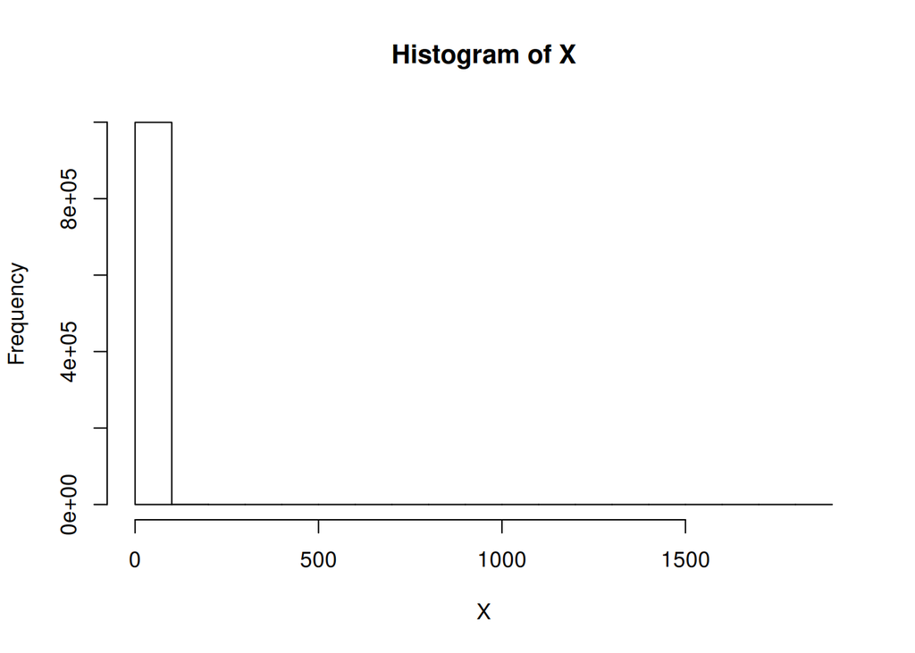

```r
hist(X)
```

Como a Pareto é uma distribuição para valores extremos, visualizações de toda a amostra gerada por um histograma não é muito informativa, pois a maior observação chega a ter valor 1849.7575797. Teoricamente, quando `x = 20`, temos que $F(20) = 0.99$. De fato, nas `1e6` variáveis geradas, 0.9966% são maiores que $20$. Assim, vamos representar o histograma até o valor `x=20` para que possamos ter uma melhor visualização dos dados.

Em seguida, define-se a densidade de Pareto

```r
  # Densidade da Pareto(2,2)
  dpareto=function(x, a=2, b=2) a*b^a/x^(a+1)
```

Por fim, comparando-se o histograma das duas distribuições, a teórica e a estimada, temos:

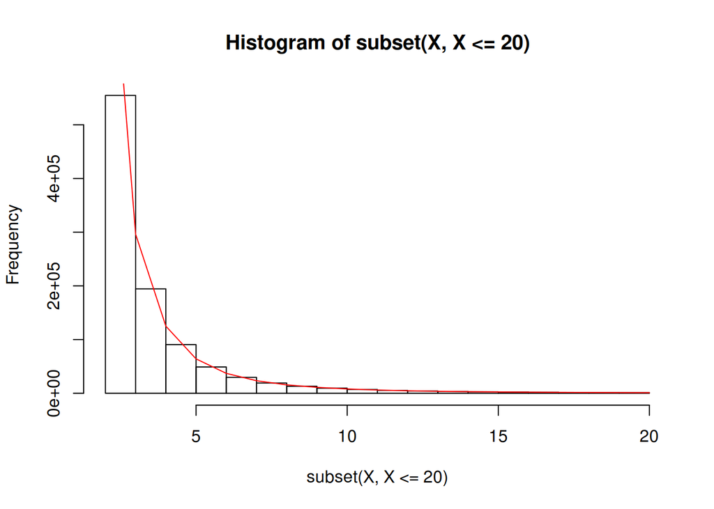

```r
# Histograma das variáveis geradas
hist(subset(X, X <= 20))
# Curva da distribuição teórica da Pareto(2,2)
lines(2:20, dpareto(2:20)*1e6, col = "red")
```

# Exercício 2

**Prove que variáveis aleatórias geradas pelo método de aceitação-rejeição são, de fato, uma amostra aleatória da densidade-alvo $f_{X}$.**

**Solução:**

Geramos amostras de uma distribuição de interesse a partir da geração de uma distribuição conhecida e então, rejeitando um subconjunto gerado. O mecanismo de rejeição é construído de forma que, a amostra que será aceita segue a distribuição de interesse. Queremos gerar valores aleatórios de uma densidade de probabilidade $f$ definida em um algum conjunto $X$. Seja $g$ uma densidade em $X$ a partir da qual sabemos gerar valores aleatórios e com a propriedade de que $f(X) < c*g(X)$, para todo $x \in X$ e alguma constante $c$.

Geramos um elemento $x$ a partir da densidade $g$ e aceitamos o elemento com probabilidade $f(x)/cg(X)$, ou seja,

$$P(\text{Aceitar}|Y) = P\left(U < \frac{f(Y)}{cg(Y)}|Y\right) = \frac{f(Y)}{cg(Y)}.$$

Note ainda que a probabilidade total de aceitar $Y$ pode ser calculada da seguinte maneira:

$$\sum_{n}P(\text{Aceitar}|y)P(Y=y)=\sum_{n}\frac{f(y)}{cg(y)}g(y)=\frac{1}{c}.$$

Agora possuimos todos os elementos para mostrar, pelo menos no caso discreto, que o método de aceitação e rejeição gera, de fato, números aleatórios da distribuição de interesse. Para a prova utilizamos o teorema de Bayes.

Suponha um $k$ qualquer de modo que $f(k)>0$, então pelo teorema de Bayes temos que:

$$P(k|\text{Aceitar})=\frac{P(\text{Aceitar}|k)g(k)}{P(\text{Aceitar})} = \frac{[f(k)/(cg(k))]g(k)]}{1/c} = f(k)$$

Este método pode ser implementado ao gerar um elemento $u$ distribuido uniformemente em (0,1) e então, aceitamos se $u < f(x)/cg(x)$. Se $x$ é rejeitado, um novo candidato é amostrado de $g$ e repetimos o teste de aceitação. O processo se repete até que o teste de aceitação gere a quantidade desejada de números aleatórios; os valores aceitos são elementos com distribuição $f$.

Algoritmo

O algoritmo do método de aceitação-rejeição pode ser apresentado nos passos abaixo.

1. Simula-se o valor $x$ com densidade $g$ }
2. Gera-se um número aleatório $u \sim \text{Unif}(0,1)$}
3. Se $u < f(x)/cg(x)$, aceita-se o valor e para. Caso contrário, retorna-se ao passo 1.

# Exercício 3

**O núcleo escalonado de Epanechnikov é**

$$f_{e}(x) = \frac{3}{4} (1 - x{2}),\quad |x| < 1.$$

**Uma proposta de geração de varáveis aleatórias para este caso é:**

1. $U_{1}, U_{2}, u_{3} \sim U(-1, 1)$
2. **Se** $|U_{3}| > |U_{2}|$ **e** $|U_{3}| > |U_{1}|$, **retorne** $U_{2}$. **Caso contrário, retorne** $U_{3}$.

**Solução:**

No código a seguir, simulamos uma amostra da variável Epanechnikov usando o algoritmo descrito na questão e, em seguida, construimos um histograma das variáveis geradas.

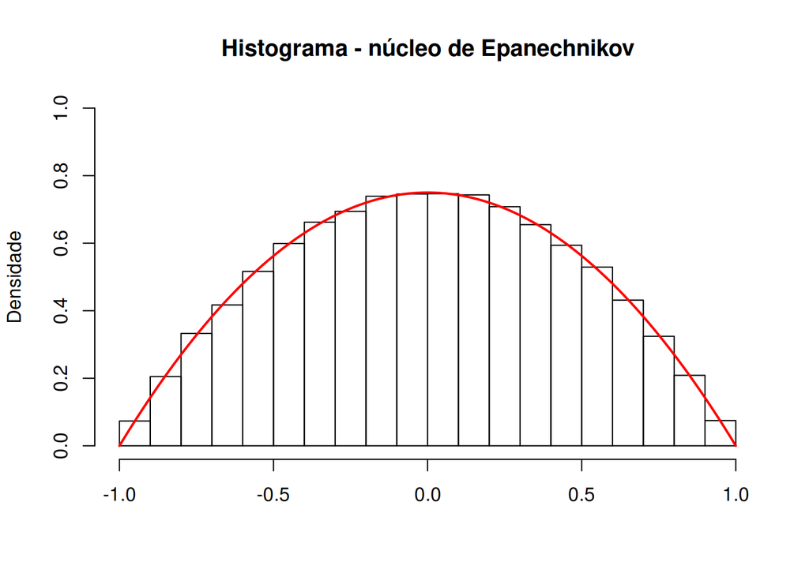

```r
# densidade Epanechnikov
d_epach = function(x) 3*(1 - x^2)/4
# função para gerar variáveis aleatórias com distribuição Epanechnikov
r_epach = function(n){
  v = rep(0,n)
  for(i in 1:n){
    u1 = runif(1,-1,1); u2 = runif(1,-1,1); u3 = runif(1,-1,1);
    if((abs(u3)>abs(u2))&&(abs(u3)>abs(u1))){
      v[i] = u2
    }else{
      v[i] = u3
    }
  }
  return(v)
}

# histograma de uma amostra da Epanechnikov e a densidade verdadeira
hist(r_epach(100000),prob=TRUE,
     main="Histograma - núcleo de Epanechnikov",
     ylim=c(0,1),ylab="Densidade",xlab="")
curve(d_epach, xlim=c(-1,1),add=TRUE,col=2,lwd=2)
```

Comparando o histograma com a densidade Epanechnikov, vemos que os valores simulados estão bastante próximos da densidade teórica.

Nessa parte vamos provar que o algoritmo de fato gera valores da densidade Epanechnikov, primeiro utilizamos integrais para encontrar a função de distribuição desejada e verificamos que o algoritmo é adequado. Depois resolvemos de outro método, utilizando estatística de ordem para facilitar a resolução .

1º Método

Sabemos que $U_i \sim U(-1,1)$, $i\in\{1,2,3\}$, daí a função de distribuição de $U_i$ é

$$F_U(u) = \frac{u+1}{2},$$

então, para $Y_i = |U_i|$ temos que

$$F_{Y_i}(y) = P(|U_i| \leq y) = P(-y \leq U_i \leq y) = F_{U_i}(y) - F_{U_i}(-y) = \left(\frac{y+1}{2}\right) - \left(\frac{-y+1}{2}\right) = y,$$

ou seja, $Y_i \sim U(0,1)$, $i\in\{1,2,3\}$.

Sendo $X$ a variável aleatória gerada de acordo com o algoritmo descrito na questão, temos que

$$X = \left\{\begin{array}{cc}
U_2 & \textrm{se } |U_3|>max\{|U_1|,|U_2|\}\\
U_3 & \textrm{se } |U_3|\leq max\{|U_1|,|U_2|\}\\
\end{array}\right.,$$

e como $U_2$ e $U_3$ são simétricas em torno de zero, pelo algoritmo temos que $X$ também o será. Logo, $P(X<0) = 1/2$. Considerando então $0<x<1$, temos que

$$\begin{align*}
P(|X|\leq x) &= P(|U_3|>max\{|U_1|,|U_2|\},|U_2|\leq x) + P(|U_3| \leq
max\{|U_1|,|U_2|\},|U_3|\leq x)\\
&= P(Y_3>max\{Y_1,Y_2\},Y_2\leq x) + P(Y_3 \leq max\{Y_1,Y_2\},Y_3\leq
x).
\end{align*}$$

Sabemos que a densidade de $Y_i$ é $f_{Y_i}(y) = 1$ para $0<y<1$. Assim, calculando a primeira probabilidade temos que

$$\begin{align*}
P(Y_3>max\{Y_1,Y_2\},Y_2\leq x) &= P(Y_1\leq Y_2 \leq Y_3, Y_2\leq x) +
P(Y_2\leq Y_2 \leq Y_3, Y_2\leq x)\\\
&= \int_{0}^{x}\int_{0}^{y_2}\int_{y_2}^{1}dy_3dy_1dy_2 +
\int_{0}^{x}\int_{y_2}^{1}\int_{y_1}^{1}dy_3dy_1dy_2\\
&= \int_{0}^{x}\int_{0}^{y_2}(1-y_2)dy_1dy_2 +
\int_{0}^{x}\int_{y_2}^{1}(1-y_1)dy_1dy_2\\
&= \int_{0}^{x}(1-y_2)y_2dy_1dy_2 +
\int_{0}^{x}\left[\left.(y_1-\frac{y_1^2}{2})\right|_{y_2}^{1}\right]
dy_2\\
&= \left.\left(\frac{y_2^2}{2}-\frac{y_2^3}{3}\right)\right|_0^x +
\int_{0}^{x}\left[1 - \frac{1}{2} - y_2 + \frac{y_2^2}{2} \right]dy_2\\
&= \frac{x^2}{2}-\frac{x^3}{3} + \left.\left[\frac{y_2}{2} -
\frac{y_2^2}{2} + \frac{y_2^3}{6} \right]\right|_0^x\\
&= \frac{x^2}{2}-\frac{x^3}{3} + \frac{x}{2}-\frac{x^2}{2} +
\frac{x^3}{6} = \frac{x}{2} - \frac{x^3}{6}\\
\end{align*}$$

Na segunda probabilidade, temos que

$$\begin{align*}
P(Y_3 \leq max\{Y_1,Y_2\},Y_3\leq x) &= P(Y_3\leq Y_2 \leq Y_1, Y_3\leq
x) + P(Y_2\leq Y_3 \leq Y_1, Y_3\leq x) \\
&+ P(Y_3\leq Y_1 \leq Y_2, Y_3\leq x) + P(Y_1\leq Y_3 \leq Y_2, Y_3\leq
x)\\
&= 2[P(Y_3\leq Y_2 \leq Y_1, Y_3\leq x) + P(Y_2\leq Y_3 \leq Y_1,
Y_3\leq x)],
\end{align*}$$

onde na primeira igualdade listamos as possíveis formas que o evento $[Y_3>max\{Y_1,Y_2\},Y_3\leq x]$ pode ocorrer e na segunda igualdade usamos o fato de $Y_1$ e $Y_2$ serem identicamente distribuídas. Daí

$$\begin{align*}
P(Y_3 \leq max\{Y_1,Y_2\},Y_3\leq x) &= 2\left[
\int_{0}^{x}\int_{y_3}^{1}\int_{y_2}^{1}dy_1dy_2dy_3 +
\int_{0}^{x}\int_{0}^{y_3}\int_{y_3}^{1}dy_1dy_2dy_3 \right]\\
&= 2\left[ \int_{0}^{x}\int_{y_3}^{1}(1-y_2)dy_2dy_3 +
\int_{0}^{x}\int_{0}^{y_3}(1-y_3)dy_2dy_3 \right]\\
&= 2\left[
\int_{0}^{x}\left[\left.(y_2-\frac{y_2^2}{2})\right|_{y_3}^{1}\right]
dy_3 + \int_{0}^{x}(1-y_3)y_3dy_3 \right]\\
&= 2\left[ \int_{0}^{x}\left[\frac{1}{2} - y_3 +
\frac{y_3^2}{2}\right]dy_3 +
\left.\left(\frac{y_3^2}{2}-\frac{y_3^3}{3}\right)\right|_0^x \right]\\
&= 2\left[ \left.\left[\frac{y_3}{2} - \frac{y_3^2}{2} +
\frac{y_3^3}{6} \right]\right|_0^x + \frac{x^2}{2}-\frac{x^3}{3}
\right]\\
&= 2\left[ \frac{x}{2} - \frac{x^2}{2} + \frac{x^3}{6} +
\frac{x^2}{2}-\frac{x^3}{3} \right] = x - \frac{x^3}{3}\\
\end{align*}$$

Portanto,

$$P(|X|\leq x) = \frac{x}{2} - \frac{x^3}{6} + x - \frac{x^3}{3} =
\frac{3x}{2} - \frac{3x^3}{6} = \frac{3x - x^3}{2},$$
e pela simetria de $X$, temos que

$$P(X\leq x) = P(X\leq 0) + P(0<X\leq x) = \frac{1}{2} + \frac{P(|X|\leq
x)}{2} = \frac{1}{2} + \frac{3x - x^3}{4},$$

onde $0<x<1$. Novamente usando o fato da distribuição de $X$ ser simétrica, temos para $0<x<1$ que

$$F_X(-x) = 1 - F_X(x) = 1 - \left[ \frac{1}{2} + \frac{3x - x^3}{4}
\right]
= \frac{1}{2} - \frac{(3x - x^3)}{4}
= \frac{1}{2} + \frac{3(-x) - (-x)^3}{4},$$

ou seja, a função de distribuição de $X$ é $F_X(x) = 1/2 + (3x - x^3)/4$, para $x\in[-1,1]$, e derivando $F_X(x)$ em relação a $x$ obtemos a função densidade de $X$, que é

$$f_X(x) = \frac{3(1-x^2)}{4}, \quad -1\leq x \leq 1,$$

assim, vemos que $X$ tem distribuição Epanechnikov, e o método de geração está correto.

2º Método

Note que o algoritmo proposto pode ser encarado como uma mistura de distribuições das estatísticas de ordem 1 e 2 para três uniformes com parametrização $(0,1)$.

Portanto, é razoável afirmar que a distribuição desejada pode ser obtida da seguinte forma:

$$\begin{equation}\label{eq:estordem}
f^{\ast}(u)=\frac{1}{2}f_{(1)}(u)+\frac{1}{2}f_{(2)}(u).
\end{equation}$$

Note que está é uma afirmação, que será provada verdadeira caso a distribuição obtida seja, de fato, a que buscamos

Sabemos que a distribuição genérica de uma estatística de ordem qualquer é dada da seguinte maneira

$$f_{(k)}(x) = \frac{n!}{(k-1)!(n-k)!} \left[F_{X}(x)\right]^{k-1}
\left[1-F_{X}(x)\right]^{n-k}f_{X}(x)$$

Adaptando para o nosso caso temos que:

$$f_{(1)}(u)=3(1-u)^{2}$$

e

$$f_{(2)}(u)=3u(1-u),$$

isso porque para uma distribuição uniforme (0,1),

$$F_{X}=\frac{x-a}{b-a}=x$$

e

$$f_{X}=\frac{1}{b-a}=1$$

Substituindo $f_{(1)}$ e $f_{(2)}$ na equação temos que:

$$\begin{equation}\label{eq:densepac}
f^{\ast}(u)=\frac{3}{2}(1-u)^{2} + \frac{3}{2}u(1-u) =
\frac{3}{2}\left(1-u^2\right), u<1
\end{equation}$$

Observe que $u$ na equação acima está definida apenas para $u<1$, mas pela simetria da distribuição podemos dividir a equação por 2 para obter a função de distribuição no domínio desejado, que é $|u|<1$.

$$f^{\ast}(u)=\frac{\frac{3}{2}(1-u)^{2} + \frac{3}{2}u(1-u)}{2} =
\frac{3}{4}\left(1-u^2\right), |u|< 1$$

# Exercício 4

** Seja $X$ uma variável aleatória não-negativa com $\mu = E(X) < \infty$. Para uma amostra aleatória $x_1, x_2, \ldots, _n$ da distribuição X, a razão de gini é:**

$$G = \dfrac{1}{2n^2}\sum_{j=1}^{n}\sum_{i =1}^{n}|x_i - x_j|.$$

**Esta quantidade é utilizada em Economia para medir a desigualdade na distribuição de renda. Observe também que $G$ pode ser reescrito como função das estatísticas de ordem:**

$$G = \dfrac{1}{n^2\mu}\sum_{i=1}^{n}(2i - n -1)x_{(i)}.$$

**Se a média é desconhecida, considere $\hat G$ como a estatística $G$, na qual subistitui-se $\mu$ por $\bar X$. Estime por simulação a média, a mediana e os decis(quantis 0,10,…,80,90,100) de $\hat G$, quanto $X$ tem:**

1. Distribuição lognormal;
2. Distribuição Uniforme;
3. Distribuição Bernoulli(0,1).

Escolha os parâmetros das distribuições log-normal e uniforme  
conforme achar adequado.

**Solução:**

Nosso interesse é estimar $\mu = E(X)$ através de simulação considerando $3$ distribuições como referência:

1. $X \sim lognormal(0,1)$;
2. $X \sim Uniforme(0,1)$;
3. $X \sim Binomial(1,0,1)$.

O algoritmo é o seguinte:

Seja a função gini abaixo com parâmetros n e dist, em que dist corresponde a qual função de refêrencia será usada, 1= logNormal, 2=Uniforme e 3=Binomial.

```r
gini=function(n,dist){
  if ((dist< 1) | (dist >3)) stop("Valor interios deve estar entre 1 e 3!")
  {gi=vector("numeric", n);
  if(dist==1){
    u=sort(rlnorm(n,0,1));
    xb=mean(u);
  } else
    {if (dist==2){
      u=sort(runif(n,0,1))
      xb=mean(u)
    }else
      {if (dist==3){
        u=sort(rbinom(n,1,0.1))
        xb=mean(u)
      }}}}
  ki=0;
  for(i in 1:n){
    ki = ki + (2*i-n-1)*u[i];
  }
  return(ki/(n^2*xb))
}
```

Dado a função acima, podemos agora calcula a estimativa da média, mediana e os decis(quantis 0,10,…,80,90,100) de $\hat G$.

- Seja $X \sim Lognormal(0,1)$

A estimativa da média de $G$ vai ser dado por $E(X) = 0.5203148$. A estimativa da mediada é igual a 0.5205176 e os quantis são dados por:

```r
decis <- matrix(round(quantile(replicate(1000, gini(1000,1)),seq(0,1,0.1)), 2), ncol = 11 )
colnames(decis) = c("  0%"  , "10%"   ,"20%",   "30%",   "40%",   "50%",
                    "60%",   "70%",   "80%", "90%",  "100%" )
rownames(decis) = c("Estimativas")
decis
```

```
              0% 10%  20%  30%  40%  50%  60%  70%  80%  90% 100%
Estimativas 0.48 0.5 0.51 0.51 0.52 0.52 0.52 0.53 0.53 0.54 0.58
```

- Seja $X \sim Uniforme(0,1)$

A estimativa da média de $G$ vai ser dado por $E(X) = 0.3333081$. A estimativa da mediada é igual a 0.3332749 e os quantis são dados por:

```r
decis <- matrix(round(quantile(replicate(1000, gini(1000,2)),seq(0,1,0.1)), 2), ncol = 11 )
colnames(decis) = c("  0%"  , "10%"   ,"20%",   "30%",   "40%",   "50%",
                    "60%",   "70%",   "80%", "90%",  "100%" )
rownames(decis) = c("Estimativas")
decis
```

```
              0%  10%  20%  30%  40%  50%  60%  70%  80%  90% 100%
Estimativas 0.31 0.32 0.33 0.33 0.33 0.33 0.33 0.34 0.34 0.34 0.36
```

- Seja $X \sim Binomial(1,0.1)$

A estimativa da média de $G$ vai ser dado por $E(X) = 0.9000177$. A estimativa da mediada é igual a 0.9001 e os quantis são dados por:

```r
decis <- matrix(round(quantile(replicate(1000, gini(10000,3)),seq(0,1,0.1)), 2), ncol = 11 )
colnames(decis) = c("  0%"  , "10%"   ,"20%",   "30%",   "40%",   "50%",
                    "60%",   "70%",   "80%", "90%",  "100%" )
rownames(decis) = c("Estimativas")
decis
```

```
              0% 10% 20% 30% 40% 50% 60% 70% 80% 90% 100%
Estimativas 0.89 0.9 0.9 0.9 0.9 0.9 0.9 0.9 0.9 0.9 0.91
```

# Exercício 5

**Construa um intervalo aproximado de confiança de 95% para a razão de Gini $\gamma = E(G)$ se $X$ segue uma distribuição log-normal com parâmetros desconhecidos. Averigue a taxa de cobertura do intervalo utilizando Monte Carlo.**

**Solução:**

```r
n = 1000 # tamanho de cada amostra

j = 1 # contador do número de amostras (escolhi, arbitrariamente, 10000)

r = 1 # registro relacionado a cada uma das amostras,
      # para média amostral
    # xbar[r] = mean(x), constante de Gini ghatC[r] = 1/(n^2*xbar[r]),
    # e o somatório de 1 a n somaAmost[i]=(2*i-n-1)*xi[i],
  # da fórmula de Gini
    # como função das estatísticas de ordem.

xbar=0
ghatC=0
G=0
somaTot=0

while(j<=10000){    # cálculo das j (10000) estimativas Gini

    x=rlnorm(n, meanlog = 0, sdlog = 1) # gera amostra aleatória
                                        # lognormal
    xbar[r]=mean(x)             # calcula x barra
    ghatC[r]=(1/(n^2*xbar[r]))      # calcula a constante

        xi=sort(x)              # ordena a amostra gerada

            somaAmost=0             # laço para cálculo do somatório
            for (i in 1:n)  {
            somaAmost[i]=(2*i-n-1)*xi[i]
                        }

            somaTot[r]=sum(somaAmost)   # registrando cada um dos somatórios

                G[j]=ghatC[r]*somaTot[r]    # cálculo da estimativa G

                    j=j+1
                    r=r+1

        }

#### Construindo o IC ((1-alpha)*100%) para G

media=mean(G)
desvio=sd(G)    # desvio padrão das estimativas G
zneg=-1.96      # z para alfa=0.025
zpos=1.96       # z para alfa=0.975

inf=media+zneg*desvio       # limite inferior do intervalo
sup=media+zpos*desvio       # limite superior do intervalo

table(G<inf) # se TRUE,
```

```
FALSE  TRUE
 9787   213
```

```r
             # valor simulado está abaixo do intervalo inferior
a=matrix(table(G<inf))

table(G>sup)    # se TRUE,
```

```
FALSE  TRUE
 9708   292
```

```r
              # valor simulado está acima do intervalo superior
b=matrix(table(G>sup))

#### valor (%) simulado fora do intervalo de 95%

percent=100*((a[2,1]+b[2,1])/10000)
percent
```

```
[1] 5.05
```

# Exercício 6

**Use simulação de Monte Carlo para investigar a taxa empírica do Erro Tipo I do teste-*t*. Verifique se estes são aproximadamente iguais ao valor nominal $\alpha$ quando a população amostrada não segue uma distribuição normal. Discuta estes casos quando as distribuições seguem:**

- $\chi^{2}$ (1)
- Uniforme (0, 2)
- Exponencial (1)

**Para cada caso, teste $H_{0}: \mu = \mu_{0}$ vs. $H_{1}: \mu \neq \mu_{0}$, onde $\mu_{0}$ é a esperança de $\chi^{2}$ (1), Uniforme (0, 2) e Exponencial (1), respectivamente.**

**Solução:**

O teste-*t* é um teste utilizado para rejeitar ou não uma hipótese nula quando a estatística de teste segue uma distribuição *t* de Student.

No nosso caso, faremos o teste sob $H_{0}: \mu = 1$ vs. $H_{1}: \mu \neq 1$ e considerando a variância populacional $\sigma^{2}$ desconhecida. Com as parametrizações consideradas, todas as distribuições estudadas tem esperança 1. Vamos verificar a taxa empírica do Erro do Tipo I quando a população não segue uma distribuição normal.

Seja $\ x_{1}, x_{2}, \dots, x_{n}$ valores amostrais da distribuição estudada, então a estatística do teste será dada por:

$$T = \frac{\bar{X} - \mu}{S / \sqrt{n}} \sim t_{(n - 1)}.$$

Observe que rejeitamos $H_{0}$ para grandes valores da estatística de teste $T$, indicando que a média não é igual a 1.

No nosso estudo do Erro do tipo I empírico, geraremos as amostras a partir das distribuições que tem média (verdadeira) $\mu = 1$. Faremos então o teste e calcularemos a proporção de vezes que o teste rejeita $H_0$. Esta proporção será a estimativa do Erro do Tipo I.

Repetiremos o processo para uma amostra de tamanho $n = 20, 100, \text{e } 500$, 10000 mil vezes. Faremos isso para cada das distribuições e comentaremos então os resultados.

```r
# <r code> ========================================================== #
## Criando a função que gera as amostras,
## calcula a estatística do teste e obtém as taxas do Erro Tipo 1
ex6 <- function(type = "normal", size, mu = 1, m = 10000, alpha = .05){
  t.stat <- replicate(m, {
    switch(type
           , normal = {x <- rnorm(n = size, mean = 1, sd = .25)}
           , chi = {x <- rchisq(n = size, df = 1)}
           , unif = {x <- runif(n = size, min = 0, max = 2)}
           , expo = {x <- rexp(n = size, rate = 1)}
           )
    ( mean(x) - mu ) / ( sd(x) / sqrt(size) )
  })
  mean( t.stat > qt(1 - alpha, size - 1) )
# </r code> ========================================================= #
}
```

```r
# <r code> ========================================================== #
## Gerando as amostras,
## calculando a estatística do teste e obtendo as taxas do Erro Tipo 1
set.seed(93)

results <- data.frame(
  `Distribuição` = rep(
    c("Normal", "Chi quadrado", "Uniforme", "Exponencial"), each = 3)
  , `Tamanho amostral` = rep(c("20", "100", "500"), 4)
  , `Taxa empírica` = c(
    unlist(lapply(c(20, 100, 500), ex6, type = "normal"))
    , unlist(lapply(c(20, 100, 500), ex6, type = "chi"))
    , unlist(lapply(c(20, 100, 500), ex6, type = "unif"))
    , unlist(lapply(c(20, 100, 500), ex6, type = "expo"))
  ))
results$`Distribuição` <-
  with(results
       , factor(`Distribuição`, levels(`Distribuição`)[c(3, 1, 4, 2)]))
results$`Tamanho.amostral` <-
  with(results, factor(
    `Tamanho.amostral`, levels(`Tamanho.amostral`)[c(2, 1, 3)]))
results
# </r code> ========================================================= #
```

```
   Distribuição Tamanho.amostral Taxa.empírica
1        Normal               20        0.0489
2        Normal              100        0.0469
3        Normal              500        0.0459
4  Chi quadrado               20        0.0134
5  Chi quadrado              100        0.0250
6  Chi quadrado              500        0.0383
7      Uniforme               20        0.0496
8      Uniforme              100        0.0518
9      Uniforme              500        0.0497
10  Exponencial               20        0.0198
11  Exponencial              100        0.0313
12  Exponencial              500        0.0441
```

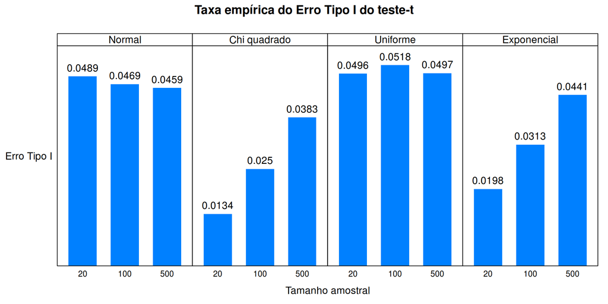

```r
# <r code> ========================================================== #
## Visualizando os resultados graficamente
library(latticeExtra)

barchart(`Taxa.empírica` ~ `Tamanho.amostral` | `Distribuição`
         , data = results
         , horizontal = FALSE
         , border = "transparent"
         , col = "#0080ff"
         , scales = list(y = list(draw = FALSE))
         , xlab = "Tamanho amostral"
         , ylab = list("Erro Tipo I", rot = 0)
         , main = "Taxa empírica do Erro Tipo I do teste-t"
         , strip = strip.custom(bg = "white")
         , ylim = c(0, max(results$`Taxa.empírica`) + .005)
         , layout = c(4, 1)
         , panel = function(...){
           panel.barchart(...)
           args <- list(...)
           panel.text(args$x, args$y, args$y, pos = 3)
         })
# </r code> ========================================================= #
```

Observe que tanto a distribuição Uniforme (0, 2) quanto a Normal (1, 0.25) foram as que tiveram os valores mais próximos do valor esperado $\alpha = 5\%$. Isso talvez pode ser explicado pela simetria das distribuições em relação à média. Como a $\chi^{2}$ (1) e Exponencial (1) não são simétricas, tiveram resultados mais longe do esperado.

# Exercício 7

**Determinar uma estimativa de Monte Carlo para:**

$$\int_{0}^{\pi/3}\sin (t) dt$$

**e comparar a estimativa com o valor exato da integral.**

**Solução:**

Primeiramente vamos fazer uma tranformação de variáveis, de modo que o novo intervalo de integração seja (0,1)

$$y = \frac{t-0}{\frac{\pi}{3}-0} = \frac{3t}{\pi} \\ dy= \frac{3}{\pi} dt$$

Dessa forma, temos que

$$\int_{0}^{\pi/3}\sin (t) dt = \frac{\pi}{3}\int_{0}^{1}\sin (\frac{y\pi}{3}) dy$$

O que vamos fazer agora é

- Gerar $y_{i}$ com distribuição U[0,1];
- Obter $g(y_{i})= sin(\frac{y_{i}\pi}{3})$;
- Obter a estimativa da integral: $\hat{\theta}=\frac{\pi}{3}g(\bar{y})$;
- Calcular o valor exato da integral.

```r
n <- 1e7
y <- runif(n, 0, 1) #gerando U[0,1]
gx <- sin(y*(pi/3)) #aplicando na função
gb <- mean(gx) # calculando a média
theta <- gb*(pi/3) #estimativa da integral pelo método de Monte Carlo
theta
```

```
[1] 0.4999327
```

```r
valor_exato  <- (-cos(pi/3)+cos(0)) #Valor exato da integral
valor_exato
```

```
[1] 0.5
```

# Exercício 8

Gostaríamos de estimar

$$\Phi(x)=P(X\leq x)=\int_{-\infty}^x \dfrac{1}{\sqrt{2\pi}}\exp(-t^2/2) dt,$$

Pela simetría da distribuição normal padrão essa estimação se reduce a estimar para $x>0$

$$\begin{equation}
\theta=\int_0^x \dfrac{1}{\sqrt{2\pi}}\exp(-t^2/2) dt,
\end{equation}$$

vamos obter duas estimativas de $\theta$, a primeira usando uma a.a. de uniformes em (0,1) e outra gerando uniformes em $(0,x).$, para um valor de $x>0.$ previamente fixado. Finalmente para obtermos as estimativas para $\Phi(x)$ usamos

$$\widehat{\Phi(x)}=\hat{\theta}+0.5,$$
a implementação do algoritmo usando estimação por Monte Carlo é apresentado a continuação, para o valor $x=1.5$.

```r
#usando uniformes (0,1)

m <-1000;
n <-200;
x <-1.5;
alpha=0.05;
cdf <- replicate(m, {
  u <-runif(n)
  g<-(x*exp((-(u*x)^2)/2))/sqrt(2*pi)
  mean(g)+0.5})
media1 <- mean(cdf);
v1<- var(cdf);
ic1<-round(media1 + c(-1,1) * qnorm(1-alpha/2,mean=0,sd=1) * sqrt(v1/m), 4)
print(media1)
```

```
[1] 0.9334386
```

```r
print(v1)
```

```
[1] 8.615364e-05
```

```r
print(ic1)
```

```
[1] 0.9329 0.9340
```

```r
#Usando uniformes (0,x)

x <- 1.5;
n <-1000;
m <-200;
alpha=0.05;
cdf <- replicate(m, {
  u <-runif(n, 0, x)
  g<-(exp((-(u)^2)/2))/sqrt(2*pi)
  x*mean(g)+0.5})
media2 <- mean(cdf);
v2<- var(cdf);
ic2<-round(media2 + c(-1,1) * qnorm(1-alpha/2,mean=0,sd=1) *sqrt(v2/m), 4)
print(media2)
```

```
[1] 0.9331383
```

```r
print(v2)
```

```
[1] 1.438044e-05
```

```r
print(ic2)
```

```
[1] 0.9326 0.9337
```

# Exercício 9

Use o Método de Variáveis Antitéticas para estimar

$$\int_{0}^{1} \frac{e^{-x}} {1+x^2} dx$$

e determine o percentual de redução de variância quando compara-se este resultado àquele sem a técnica de redução de variância.

**Solução:** Queremos estimar
$$\theta= E\Big[\frac{e^{-U}} {1+U^2}\Big] = \int_{0}^{1} \frac{e^{-u}} {1+u^2} du$$
expressão na qual $U \sim (0,1)$.

Se $m$ replicatas de Monte Carlo são necessárias, então:

1. Gere $u_1,…,u_{m/2} \sim U(0,1)$

```r
m = 1e6
U = runif(m/2)
```

2. Gere $Y_i=\frac{e^{-u}} {1+u^2}$
3. Gere $W_i=\frac{e^{-(1-u)}} {1+(1-u)^2}$
4. Retornar $\widehat{\theta}=\frac{2}{m}\sum_{i=1}^{m/2} (\frac{Y_i+W_i}{2})$.

```r
theta.estimado <- function(U){

  y =exp(-U)/(1+U^2)
  w =exp(U-1)/(1+(1-U)^2)
  return(mean((y+w)/2))
}

theta.estimado(U)
```

```
[1] 0.5249207
```

Assim encontramos a estimativa de 0.5249207 para $\theta$.

Para comparar o estimador encontado com aquele sem a técnica de redução de variância replicamos 1000 vezes a simulação e calculamos a variância amostral para cada estimador.

```r
theta.sem.red <- function(U){
  fx =exp(-U)/(1+U^2)
  return(mean(fx))
}
mc1 = replicate(1000, theta.sem.red(runif(1000)))
mc2 = replicate(1000, theta.estimado(runif(1000)))
```

Seja $\widehat{\theta}_1$ o estimador encontrado sem a técnica de redução de variância e $\widehat{\theta}_2$ o estimador com redução de variância, encontramos que $SD(\widehat{\theta}_1)$=0.00809 e $SD(\widehat{\theta}_2)$=0.00101.

Se temos 2 estimadores, $θ_1$ e $θ_2$, e $V(θ_2)<V(θ_1)$, então o percentual de redução de variância é:

$$100 (\frac{V(\widehat{\theta}_1)-V(\widehat{\theta}_2)} {V(\widehat{\theta}_1)})\%$$

Portanto, temos que o percentual de redução de variância será de 98.43% :

```r
round(100*(var(mc1)-var(mc2))/var(mc1), 2)
```

```
[1] 98.43
```

# Exercício 10

A questão pede que estimemos a esperança de $X^2$ de uma distribuição normal padrão definida no intervalo $[1,\infty)$ pelo método da amostragem por importância. A esperança a ser estimada é descrita a seguir:

$$E(X^2) = \int_{1}^{\infty} \frac{{x^2}}{\sqrt{2\pi}}exp \left( \frac{-x^2}{2} \right)$$
Uma distribuição interessante para ser utilizada é a distribuição normal padrão truncada em 1, porque possui o mesmo suporte que a densidade que temos $[0,\infty)$ e, além disso, a razão entre ambas gera uma expressão estável. A estabilidade se dá pela semelhança entre a distribuição normal que a questão oferece e a distribuição normal truncada.

A razão referida anteriormente pode ser definida, com alguma simplificação de notação, da seguinte maneira:

$$R = \frac{g(x)}{f(x)},$$
onde $g(x)$ denota a distribuição original, no caso a distribuição normal padrão pré multiplicada por $x^2$ e $f(X)$ a função de importância. É importante observar que a variância do estimador depende de $R$, logo é aconselhável obter razões $R$ mais estáveis.

A implementação do algoritmo de importância segue abaixo:

```r
MCNormTruncX2 <- function(n,lower=1,upper=Inf,media=0,dp=1){
# verificando se o pacote truncnorm precisa ser instalado
if("truncnorm" %in% rownames(installed.packages())==FALSE)
{install.packages("truncnorm");library(truncnorm)}
  else library(truncnorm)

rtn      <- rtruncnorm(n=n,a=lower,b=upper,mean=media,sd=dp)
int1     <- ((rtn^2)*dnorm(x=rtn,mean=media,sd=dp))/dtruncnorm(x=rtn,
        a=lower,b=upper,mean=media,sd=dp)
impMC1   <- mean(int1)
varinf1  <- var(int1)/n

result   <- list(thetahat = impMC1,
                 varhat   = varinf1)
return(result)
}
cbind(rbind(MCNormTruncX2(n=100),MCNormTruncX2(n=1e4),MCNormTruncX2(n=1e6)),c(100,1e4,1e6))
```

```
     thetahat  varhat
[1,] 0.3821419 0.0007770894 100
[2,] 0.3987725 6.618896e-06 10000
[3,] 0.4007732 6.848385e-08 1e+06
```

Note que os valores de truncagem estão pré definidos, mas nada impede que os valores de $lower$ e $upper$ sejam substituidos. O mesmo ocorre com os valores da média e do desvio-padrão. Note também que os resultados indicam que o estimador é consistente, pois à medida que se eleva $n$, a variância do estimador reduz consideravelmente.